# chapter5

Julius Rissanen

24 helmikuuta 2017

# CHAPTER5 DIMENSIONALITY REDUCTION TECHNIQUES

```r
#needed libraries
library(GGally)
library(FactoMineR)
library(dplyr)
library(ggplot2)
library(tidyr)
```

First we start by downloading the ‘human’ dataset from the data wrangling part and do basic descriptive statistics

```r
human <- read.csv("data/human.csv", row.names = 1)
dim(human)
```

```
## [1] 155   8
```

```r
str(human)
```

```
## 'data.frame':    155 obs. of  8 variables:
##  $ eduF2M          : num  1.007 0.997 0.983 0.989 0.969 ...
##  $ labourF2m       : num  0.891 0.819 0.825 0.884 0.829 ...
##  $ eduexpect       : num  17.5 20.2 15.8 18.7 17.9 16.5 18.6 16.5 15.9 19.2 ...
##  $ lifexpect       : num  81.6 82.4 83 80.2 81.6 80.9 80.9 79.1 82 81.8 ...
##  $ gni             : int  64992 42261 56431 44025 45435 43919 39568 52947 42155 32689 ...
##  $ mortality       : int  4 6 6 5 6 7 9 28 11 8 ...
##  $ adole_birth     : num  7.8 12.1 1.9 5.1 6.2 3.8 8.2 31 14.5 25.3 ...
##  $ parlia_represent: num  39.6 30.5 28.5 38 36.9 36.9 19.9 19.4 28.2 31.4 ...
```

```r
colnames(human)
```

```
## [1] "eduF2M"           "labourF2m"        "eduexpect"
## [4] "lifexpect"        "gni"              "mortality"
## [7] "adole_birth"      "parlia_represent"
```

Our dataset has 155 countries and 8 variables for each of them. The data has no missing values because countries with them were cleaned in the earlier data wrangling part. Our variables describe characteristics in education, health, economy, political activity and gender equality

Next we do some graphical exploratory analysis

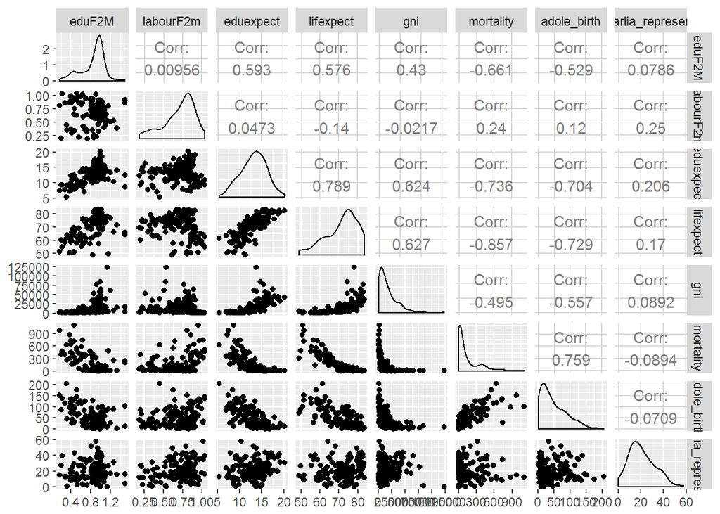

```r
ggpairs(human)
```

There also exist high negative correlations between adolescent birth rate, expected education duration, life expectancy and maternal mortality

Next we do principal component analysis without scaling our variables

```r
pca_human <- prcomp(human)
summary(pca_human)
```

```
## Importance of components:
##                              PC1      PC2   PC3   PC4   PC5   PC6    PC7
## Standard deviation     1.854e+04 185.5219 25.19 11.45 3.766 1.566 0.1912
## Proportion of Variance 9.999e-01   0.0001  0.00  0.00 0.000 0.000 0.0000
## Cumulative Proportion  9.999e-01   1.0000  1.00  1.00 1.000 1.000 1.0000
##                           PC8
## Standard deviation     0.1591
## Proportion of Variance 0.0000
## Cumulative Proportion  1.0000
```

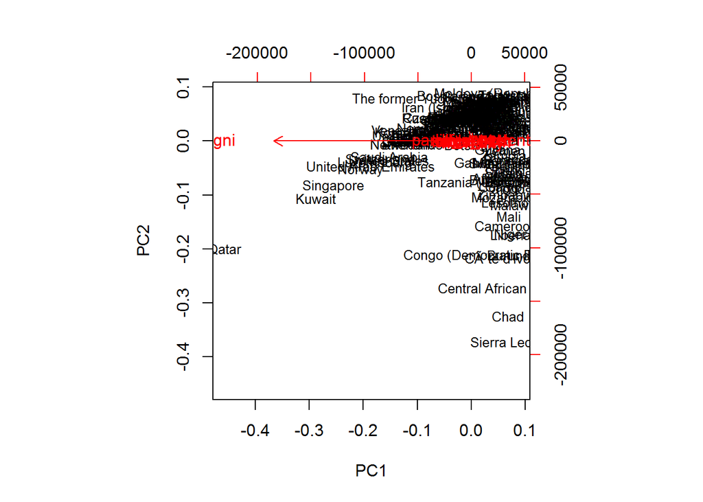

```r
biplot(pca_human, choices = 1:2, cex = c(0.8,1))
```

Using non-standardized data confirms the notion that it’s not advisable to use non-standardized data with pca. Huge differences in variable scales makes all the proportions of variance explained by each principal component minimal (after the first one). Biplot visualises the same thing by showing that GNI is the main (only) driver in variance.

Next we scale the data and repeat the procedure

```r
human_scaled <- scale(human)
pca_human_scaled <- prcomp(human_scaled)
summary(pca_human_scaled)
```

```
## Importance of components:
##                           PC1    PC2     PC3     PC4     PC5     PC6
## Standard deviation     2.0708 1.1397 0.87505 0.77886 0.66196 0.53631
## Proportion of Variance 0.5361 0.1624 0.09571 0.07583 0.05477 0.03595
## Cumulative Proportion  0.5361 0.6984 0.79413 0.86996 0.92473 0.96069
##                            PC7     PC8
## Standard deviation     0.45900 0.32224
## Proportion of Variance 0.02634 0.01298
## Cumulative Proportion  0.98702 1.00000
```

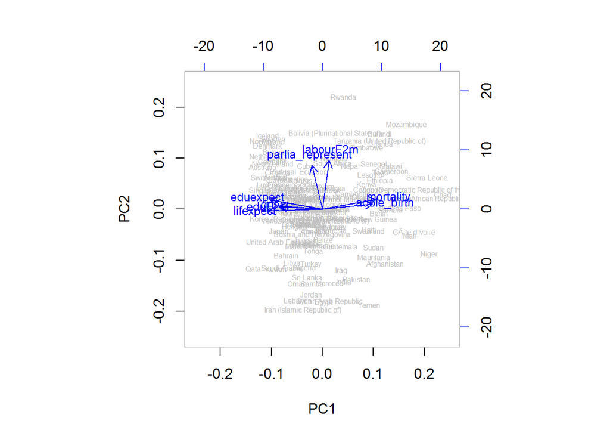

```r
biplot(pca_human_scaled, choices = 1:2, cex = c(0.5,0.8), col = c("grey", "blue"), xlim  = c(-0.25, 0.25), ylim  = c(-0.25, 0.25))
```

Above results can be intepreted as that first principal component explains 53.6% of the variance, 2nd 16.2% and 3rd 9.6%.

Biplot reveals that first principal component consists mostly of expected education duration, education gender gap, GNI, life expectancy, child mortality and adolescent birth rate.

2nd principal component consists of labour gender equality and women represented in parliament

General explanations for principal components could be seen as: 1st PC could be viewed as human development and 2nd one as governmental and labour gender equality.

Tea time!

Exploratory and descriptive data analysis:

```r
data("tea")
dim(tea)
```

```
## [1] 300  36
```

```r
colnames(tea)
```

```
##  [1] "breakfast"        "tea.time"         "evening"
##  [4] "lunch"            "dinner"           "always"
##  [7] "home"             "work"             "tearoom"
## [10] "friends"          "resto"            "pub"
## [13] "Tea"              "How"              "sugar"
## [16] "how"              "where"            "price"
## [19] "age"              "sex"              "SPC"
## [22] "Sport"            "age_Q"            "frequency"
## [25] "escape.exoticism" "spirituality"     "healthy"
## [28] "diuretic"         "friendliness"     "iron.absorption"
## [31] "feminine"         "sophisticated"    "slimming"
## [34] "exciting"         "relaxing"         "effect.on.health"
```

To make it simple we take subset of data consisting of 6 variables

1. sex
2. tea.time
3. healthy
4. price
5. iron.absorption
6. spirituality

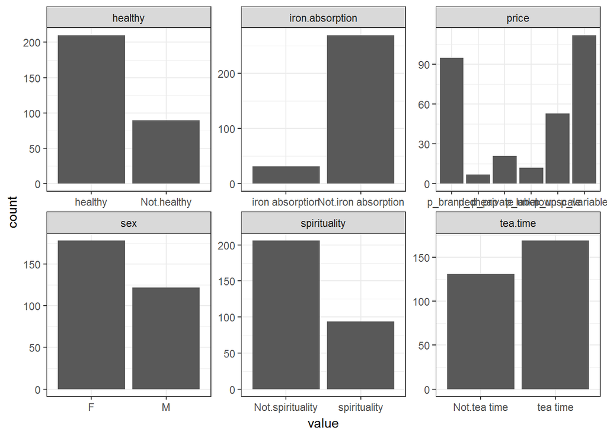

```r
#variables which we keep
keep_variables <- c("sex", "tea.time", "healthy", "price", "iron.absorption", "spirituality")
tea_6 <- select(tea, one_of(keep_variables))

gather(tea_6) %>% ggplot(aes(value)) + facet_wrap("key", scales = "free") + geom_bar() + theme_bw()
```

Our final dataset includes 6 variables for 300 persons. Only price variable is multilevel, other’s were binary. Variable graph is fortunately self explanatory for visualisation in this small dataset.

Next we run multiple correspondence analysis (MCA). With MCA we can analyze categorical variables compared to PCA which works only with continuos variables.

```r
mca <- MCA(tea_6, graph = FALSE)
summary(mca)
```

```
##
## Call:
## MCA(X = tea_6, graph = FALSE)
##
##
## Eigenvalues
##                        Dim.1   Dim.2   Dim.3   Dim.4   Dim.5   Dim.6
## Variance               0.225   0.197   0.185   0.172   0.167   0.166
## % of var.             13.485  11.835  11.116  10.327  10.044   9.972
## Cumulative % of var.  13.485  25.319  36.435  46.762  56.807  66.778
##                        Dim.7   Dim.8   Dim.9  Dim.10
## Variance               0.162   0.149   0.137   0.107
## % of var.              9.693   8.915   8.191   6.422
## Cumulative % of var.  76.471  85.386  93.578 100.000
##
## Individuals (the 10 first)
##                    Dim.1    ctr   cos2    Dim.2    ctr   cos2    Dim.3
## 1               |  1.039  1.600  0.233 |  0.061  0.006  0.001 | -0.047
## 2               | -0.033  0.002  0.001 | -0.242  0.099  0.076 |  0.061
## 3               | -0.507  0.381  0.372 |  0.085  0.012  0.010 |  0.078
## 4               |  0.572  0.485  0.274 | -0.405  0.277  0.137 |  0.690
## 5               |  0.614  0.559  0.249 |  0.212  0.076  0.030 |  0.750
## 6               |  0.674  0.673  0.160 |  0.003  0.000  0.000 | -0.333
## 7               |  0.072  0.008  0.006 |  0.103  0.018  0.013 |  0.117
## 8               | -0.507  0.381  0.372 |  0.085  0.012  0.010 |  0.078
## 9               |  0.403  0.241  0.100 |  0.864  1.263  0.458 | -0.159
## 10              |  0.835  1.035  0.498 | -0.079  0.011  0.004 | -0.237
##                    ctr   cos2
## 1                0.004  0.000 |
## 2                0.007  0.005 |
## 3                0.011  0.009 |
## 4                0.856  0.398 |
## 5                1.011  0.372 |
## 6                0.200  0.039 |
## 7                0.025  0.017 |
## 8                0.011  0.009 |
## 9                0.046  0.016 |
## 10               0.101  0.040 |
##
## Categories (the 10 first)
```

[output cut: 16 more lines]

```
## healthy           0.567 -13.016 |  -0.046   0.135   0.005  -1.225 |
## Not.healthy       0.567  13.016 |   0.108   0.316   0.005   1.225 |
## p_branded         0.225  -8.206 |  -0.779  17.298   0.281  -9.173 |
## p_cheap           0.012   1.860 |  -2.059   8.902   0.101  -5.504 |
## p_private label   0.037   3.328 |  -0.297   0.557   0.007  -1.411 |
## p_unknown         0.030   3.018 |   0.440   0.698   0.008   1.555 |
##
## Categorical variables (eta2)
##                   Dim.1 Dim.2 Dim.3
## sex             | 0.653 0.001 0.002 |
## tea.time        | 0.447 0.187 0.000 |
## healthy         | 0.003 0.567 0.005 |
## price           | 0.158 0.273 0.557 |
## iron.absorption | 0.086 0.106 0.047 |
## spirituality    | 0.001 0.050 0.499 |
```

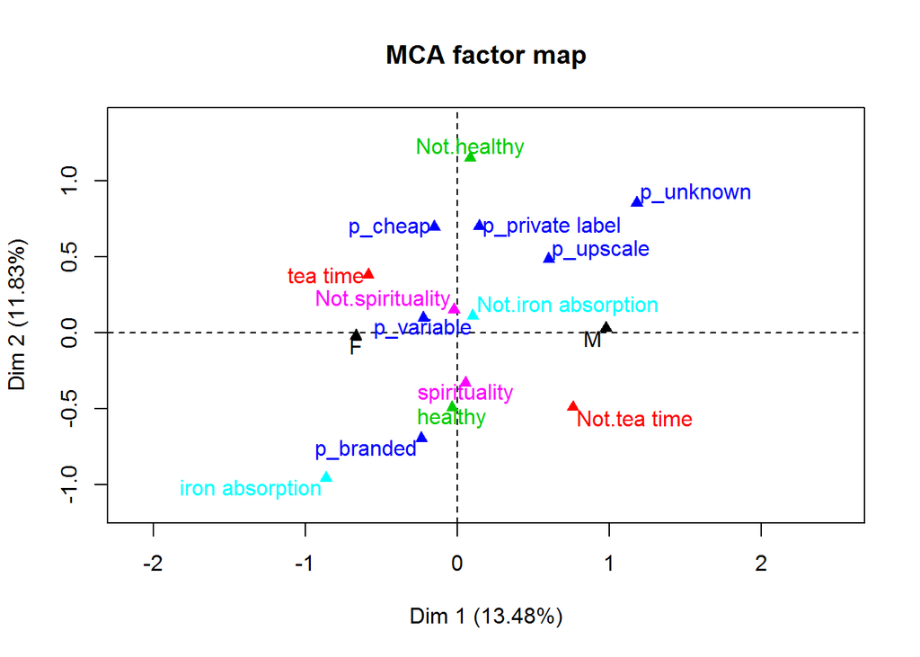

```r
plot(mca, invisible = c("ind"), habillage = c("quali"))
```

Variables don’t load really smoothly on the dimensions. Reason could be that I accidentally tried to choose different kind of variables. Dimension 1 makes the most clear difference for sex (65% eta value) and tea.time (44%). 2nd dimension looks to be mostly about healthiness and price.